# Gradient Boosted Model Prediction

Ross Cooper 54907605

2024-06-03

# Loading in Data

```r
load(file="StudentGrades.RData")
head(studentgrades)
```

```
##                         Student_ID Major.1 Major.2 Minor Honors MATH.100
## 1 000A9C28CE68BB35B3AB998F54E36069    <NA>    <NA>  <NA>  FALSE       NA
## 2 000D7939BE85535C003A41802D19B0C7    <NA>    <NA>  <NA>  FALSE       67
## 3 0013CBA29E4FB1FC58289E33784E8A60    COSC    <NA>  PSYC  FALSE       65
## 4 00145EE0B1F088A2E5FA612989E4E43E    <NA>    <NA>  <NA>  FALSE       NA
## 5 002C748932B826B51DD7A82D88F666A0    BIOC    <NA>  <NA>  FALSE       NA
## 6 002F3314F385679CFC31BA81DDBF2C0F    <NA>    <NA>  <NA>  FALSE       87
##   MATH.101 COSC.111 COSC.121 MATH.221 STAT.230 MATH.200 COSC.221 COSC.222
## 1       NA       NA       NA       NA       NA       NA       NA       NA
## 2       81       NA       NA       NA       NA       NA       NA       NA
## 3       84       77       86       73       78       72       62       81
## 4       NA       NA       NA       NA       NA       NA       NA       NA
## 5       NA       NA       NA       NA       76       NA       NA       NA
## 6       85       NA       NA       NA       NA       NA       NA       NA
##   COSC.122 COSC.304 COSC.211 COSC.101 STAT.121 COSC.341 COSC.310 DATA.101
```

[output cut: 90 more lines]

# Gradient Boosted Model

## Summary of the Boosting Process

1. **Initialize the model** with a constant value, typically the mean of the target values for regression:

$$F_0(x) = \arg\min_{c} \sum_{i=1}^{N} L(y_i, c)$$

2. **For $m = 1$ to $M$ (number of boosting iterations)**:
   - Compute the residuals $r_i^m$
   - For squared error loss, this simplifies to:
     $$r_i^m = y_i - F_{m-1}(x_i)$$
   - Fit a base learner $h_m(x)$ to the residuals.
   - Update the model via gradient decent:

$$F_{m}(x) = F_{m-1}(x) + \nu h_m(x)$$

3. **Final prediction** is the sum of all base learners:

$$\hat{y} = F_M(x) = \sum_{m=1}^{M} \nu h_m(x)$$

## Shrinkage and Iterations

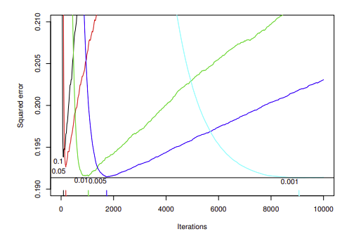

Figure 3: Out-of-sample predictive performance by number of iterations and shrinkage. Smaller values of the shrinkage parameter offer improved predictive performance, but with decreasing marginal improvement. (from vignette)

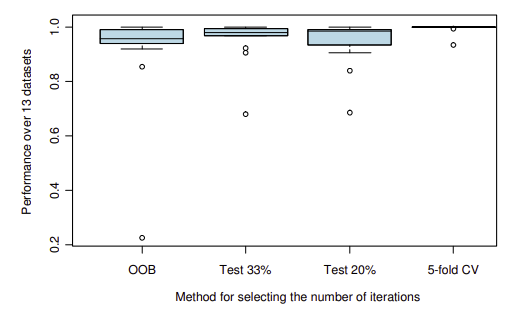

Figure 4: Out-of-sample predictive performance of four methods of selecting the optimal number of iterations. The vertical axis plots performance relative the best. The boxplots indicate relative performance across thirteen real datasets from the UCI repository. (from vignette)

The vignette recommends to use 5 or 10-fold CV if you can afford the computation time. Otherwise OOB is a good conservative choice.

## GBM Data Prep

```r
# Identifying the course of interest
COI <- "STAT.230"
coursegrades <- studentgrades[!is.na(studentgrades[,COI]),-1:-5]

# remove all grades < 60%
coursegrades <- coursegrades[coursegrades$STAT.230 >= 60, ]


# dropping columns that are very sparse (pct % are NA)
pct <- 0.95
courses <- numeric(0)
for (i in 1:ncol(coursegrades)) {
  if(is.na(coursegrades[,i]) |> sum()  > nrow(coursegrades)*pct){
    courses <- c(courses,i)
  }
}

coursegrades <- coursegrades[,-courses]


# Removing all course columns of higher years
YOI <- as.integer(substr(strsplit(COI, split = ".", fixed = TRUE)[[1]][2],1,1))

column_names <- colnames(coursegrades)

# Extract digits after the period in column names
column_digits <- as.integer(sub("^[^.]+\\.([0-9]).*", "\\1", column_names))

# Find columns with digits not matching the selected course year
cols_to_keep <- column_names[column_digits <= YOI]

# All columns in the same year or below
coursegrades <- coursegrades[, colnames(coursegrades) %in% cols_to_keep]
```

## Iteration Graphs

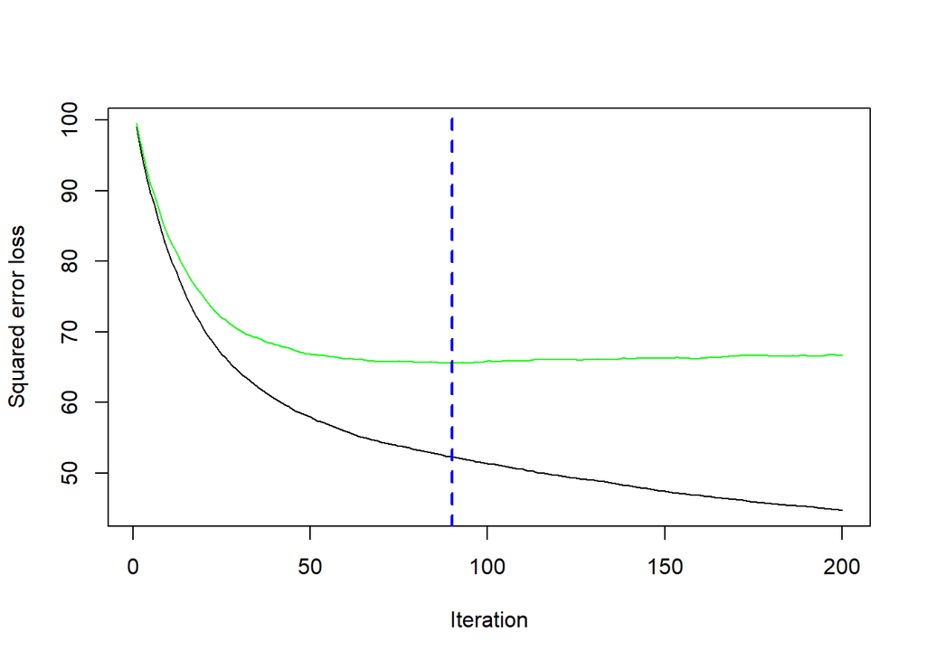

```
## [1] 90
```

```r
library(gbm)
gbm_params <- list(
  distribution = "gaussian",  # Specify the distribution for regression
  n.trees = 200,               # Number of trees (iterations)
  interaction.depth = 4,       # Maximum depth of trees
  shrinkage = 0.05,            # Learning rate (shrinkage)
  bag.fraction = 0.5,          # Fraction of training data used for each tree
  train.fraction = 1.0,        # Fraction of training data used for training (1.0 for full dataset)
  n.minobsinnode = 10          # Minimum number of observations in terminal nodes
)

# Running model first time on base params
gbm_model <- gbm(STAT.230 ~ ., data = coursegrades, distribution = gbm_params$distribution,
                 n.trees = gbm_params$n.trees, interaction.depth = gbm_params$interaction.depth,
                 shrinkage = gbm_params$shrinkage, bag.fraction = gbm_params$bag.fraction,
                 train.fraction = gbm_params$train.fraction, n.minobsinnode = gbm_params$n.minobsinnode, cv.folds = 5)


print(gbm.perf(gbm_model, method="cv"))
```

```r
print(gbm.perf(gbm_model, method="OOB"))
```

```
## OOB generally underestimates the optimal number of iterations although predictive performance is reasonably competitive. Using cv_folds>1 when calling gbm usually results in improved predictive performance.
```

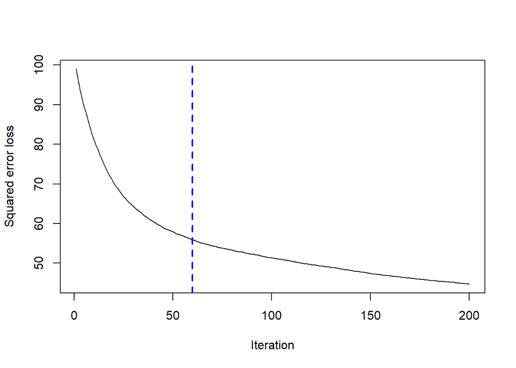

```
## [1] 60
## attr(,"smoother")
## Call:
## loess(formula = object$oobag.improve ~ x, enp.target = min(max(4,
##     length(x)/10), 50))
##
## Number of Observations: 200
## Equivalent Number of Parameters: 16.06
## Residual Standard Error: 0.06593
```

## Model Training and Prediction

```r
set.seed(5934)
n_rows <- nrow(coursegrades)
train_indices <- sample(1:n_rows, 0.8 * n_rows)  # 80% of rows for training
test_indices <- setdiff(1:n_rows, train_indices) # remaining rows for testing

library(gbm)

gbm_params <- list(
  distribution = "gaussian",  # Specify the distribution for regression
  n.trees = 200,               # Number of trees (iterations)
  interaction.depth = 4,       # Maximum depth of trees
  shrinkage = 0.05,            # Learning rate (shrinkage)
  bag.fraction = 0.5,          # Fraction of training data used for each tree
  train.fraction = 1.0,        # Fraction of training data used for training (1.0 for full dataset)
  n.minobsinnode = 10          # Minimum number of observations in terminal nodes
)

# Running model first time on base params
gbm_model <- gbm(STAT.230 ~ ., data = coursegrades, distribution = gbm_params$distribution,
                 n.trees = gbm_params$n.trees, interaction.depth = gbm_params$interaction.depth,
                 shrinkage = gbm_params$shrinkage, bag.fraction = gbm_params$bag.fraction,
                 train.fraction = gbm_params$train.fraction, n.minobsinnode = gbm_params$n.minobsinnode, cv.folds = 5)

ntrees <- gbm.perf(gbm_model,method="cv")[1]
```

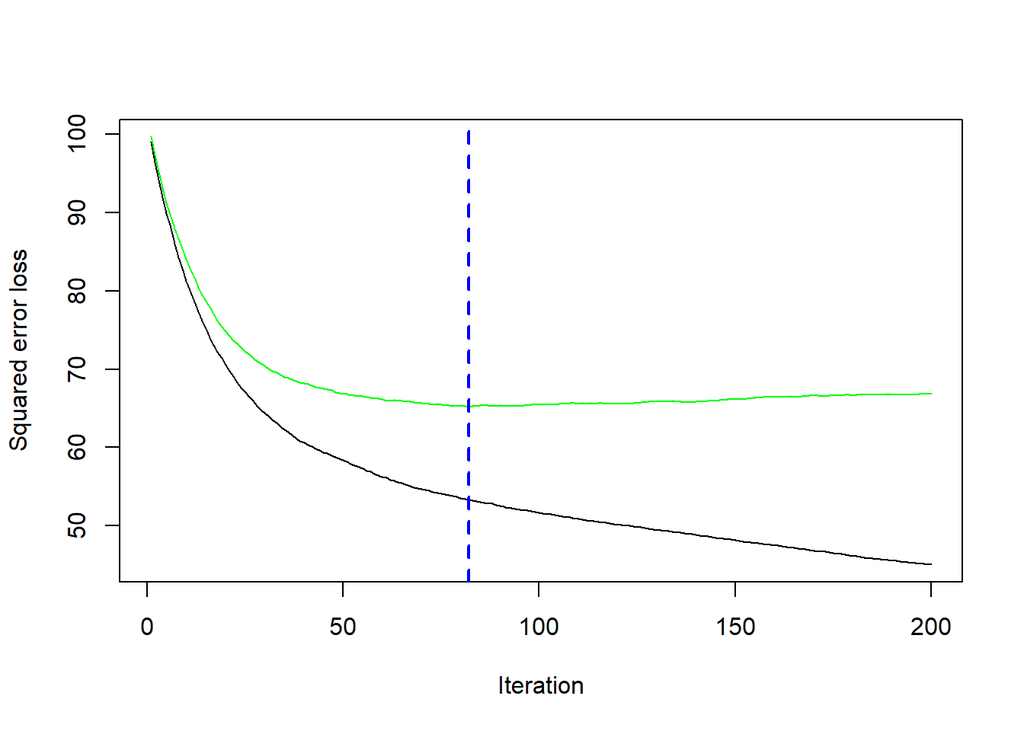

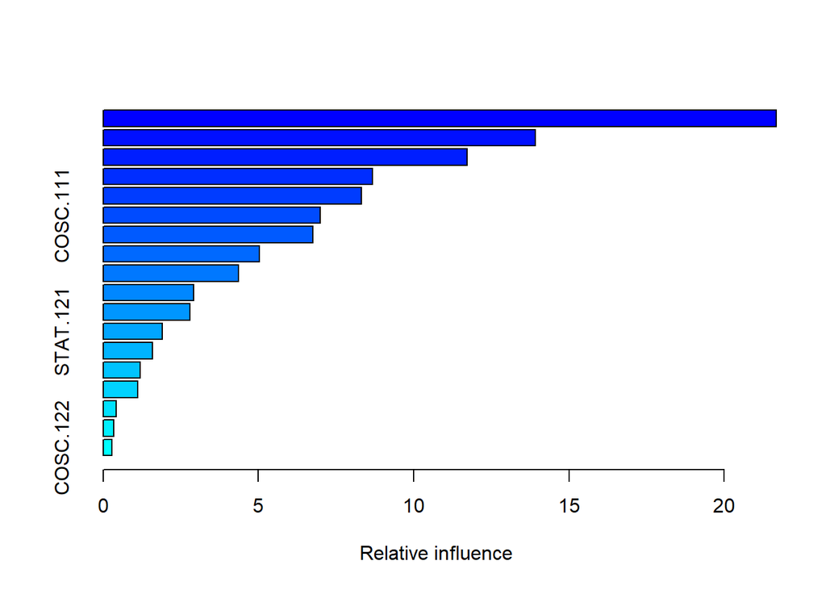

```
##               var    rel.inf
## COSC.221 COSC.221 21.6779717
## MATH.221 MATH.221 13.9285922
## COSC.211 COSC.211 11.7302026
## MATH.101 MATH.101  8.6697899
## MATH.200 MATH.200  8.3176932
## COSC.111 COSC.111  6.9911063
## COSC.222 COSC.222  6.7591851
## DATA.101 DATA.101  5.0342714
## COSC.121 COSC.121  4.3586457
## MATH.100 MATH.100  2.9211700
## MATH.220 MATH.220  2.7874897
## STAT.121 STAT.121  1.9037805
## MATH.142 MATH.142  1.5932262
## MATH.116 MATH.116  1.1842609
## MATH.225 MATH.225  1.1014305
## COSC.123 COSC.123  0.4178305
## COSC.101 COSC.101  0.3437262
## COSC.122 COSC.122  0.2796275
```

```r
# Running model a second time with optimal # of trees
gbm_model <- gbm(STAT.230 ~ ., data = coursegrades[train_indices,], distribution = gbm_params$distribution,
                 n.trees = ntrees, interaction.depth = gbm_params$interaction.depth,
                 shrinkage = gbm_params$shrinkage, bag.fraction = gbm_params$bag.fraction,
                 train.fraction = gbm_params$train.fraction, n.minobsinnode = gbm_params$n.minobsinnode, cv.folds = 5)

# Print the summary of the trained model
print(summary(gbm_model))
```

```r
# Make predictions on new data
predictions <- predict(gbm_model, newdata = coursegrades[test_indices,], n.trees = ntrees)

rmse <- sqrt(mean((predictions - coursegrades[test_indices,COI])^2))
rmse
```

```
## [1] 8.285236
```

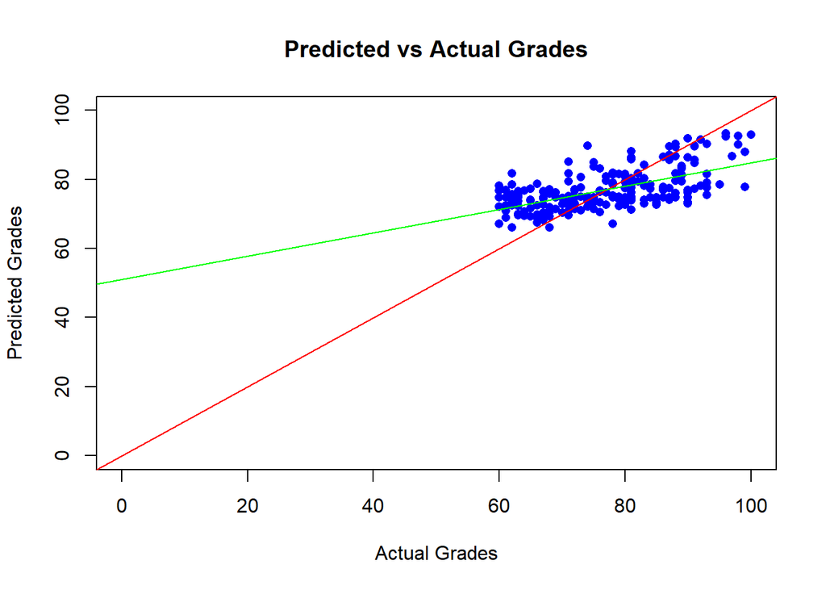

```r
actual <- coursegrades[test_indices,]$STAT.230
plot(actual, predictions, xlab = "Actual Grades", ylab = "Predicted Grades",
     main = "Predicted vs Actual Grades", pch = 16, col = "blue", xlim = c(0,100), ylim = c(0,100))
abline(0, 1, col = "red")


line.lm <- lm(predictions~actual)
abline(line.lm, col = "green")
```

## Showing results of OOB # of trees

```r
set.seed(5934)
n_rows <- nrow(coursegrades)
train_indices <- sample(1:n_rows, 0.8 * n_rows)  # 80% of rows for training
test_indices <- setdiff(1:n_rows, train_indices) # remaining rows for testing

library(gbm)

gbm_params <- list(
  distribution = "gaussian",  # Specify the distribution for regression
  n.trees = 200,               # Number of trees (iterations)
  interaction.depth = 4,       # Maximum depth of trees
  shrinkage = 0.05,            # Learning rate (shrinkage)
  bag.fraction = 0.5,          # Fraction of training data used for each tree
  train.fraction = 1.0,        # Fraction of training data used for training (1.0 for full dataset)
  n.minobsinnode = 10          # Minimum number of observations in terminal nodes
)

# Running model first time on base params
gbm_model <- gbm(STAT.230 ~ ., data = coursegrades, distribution = gbm_params$distribution,
                 n.trees = gbm_params$n.trees, interaction.depth = gbm_params$interaction.depth,
                 shrinkage = gbm_params$shrinkage, bag.fraction = gbm_params$bag.fraction,
                 train.fraction = gbm_params$train.fraction, n.minobsinnode = gbm_params$n.minobsinnode, cv.folds = 5)

ntrees <- gbm.perf(gbm_model,method="OOB")[1]
```

```
## OOB generally underestimates the optimal number of iterations although predictive performance is reasonably competitive. Using cv_folds>1 when calling gbm usually results in improved predictive performance.
```

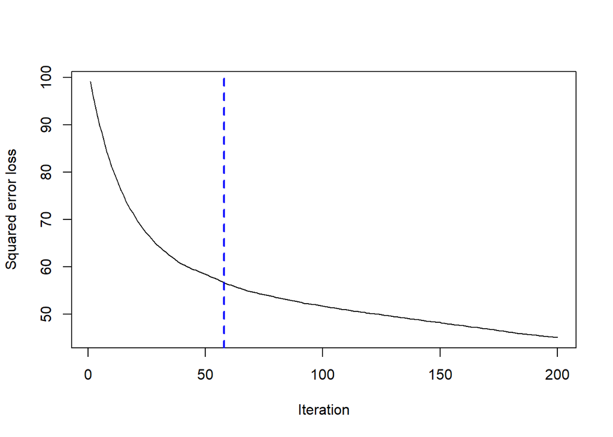

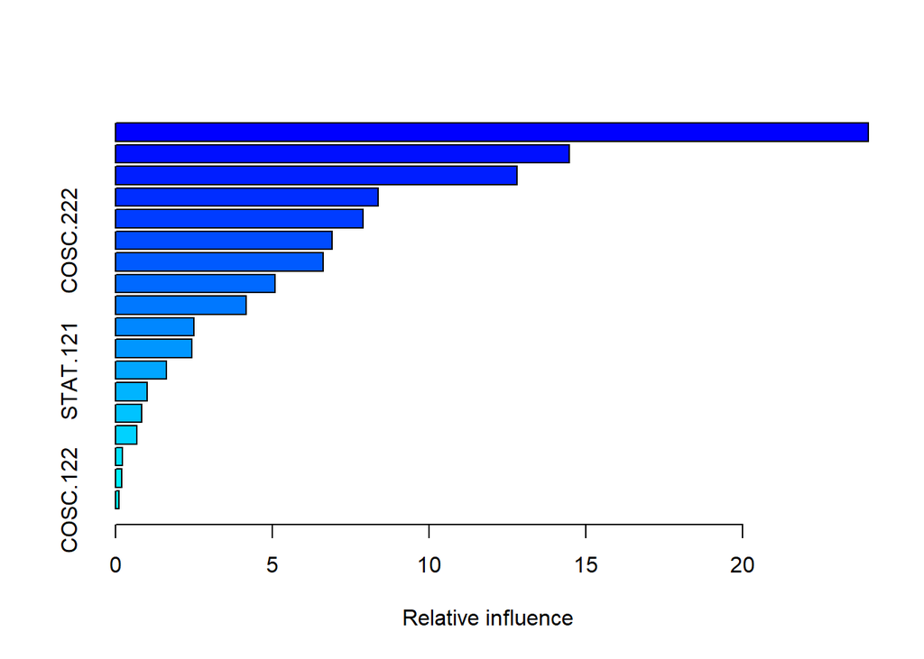

```
##               var    rel.inf
## COSC.221 COSC.221 24.0174073
## MATH.221 MATH.221 14.4759637
## COSC.211 COSC.211 12.8027455
## MATH.101 MATH.101  8.3752831
## MATH.200 MATH.200  7.9088740
## COSC.222 COSC.222  6.9138801
## COSC.111 COSC.111  6.6365858
## DATA.101 DATA.101  5.0907019
## COSC.121 COSC.121  4.1695248
## MATH.100 MATH.100  2.4925754
## MATH.220 MATH.220  2.4290479
## STAT.121 STAT.121  1.6217889
## MATH.225 MATH.225  1.0124318
## MATH.142 MATH.142  0.8341839
## MATH.116 MATH.116  0.6823082
## COSC.101 COSC.101  0.2163272
## COSC.123 COSC.123  0.2054207
## COSC.122 COSC.122  0.1149497
```

```r
# Running model a second time with optimal # of trees
gbm_model <- gbm(STAT.230 ~ ., data = coursegrades[train_indices,], distribution = gbm_params$distribution,
                 n.trees = ntrees, interaction.depth = gbm_params$interaction.depth,
                 shrinkage = gbm_params$shrinkage, bag.fraction = gbm_params$bag.fraction,
                 train.fraction = gbm_params$train.fraction, n.minobsinnode = gbm_params$n.minobsinnode, cv.folds = 5)

# Print the summary of the trained model
print(summary(gbm_model))
```

```r
# Make predictions on new data
predictions <- predict(gbm_model, newdata = coursegrades[test_indices,], n.trees = ntrees)

rmse <- sqrt(mean((predictions - coursegrades[test_indices,COI])^2))
rmse
```

```
## [1] 8.344415
```

## GBM Classification

```r
load(file = "StudentGradesLetters.RData")
studentgrades
```

[output not shown]

[output cut: 12811 more lines]

```r
library(dplyr)
convert_to_binary <- function(x) {
  ifelse(x == "F", 0, 1)
}

# Apply the conversion function to all columns except the first 5 columns
studentgrades <- studentgrades %>% mutate(across(-c(1:5), convert_to_binary))
```

```r
# Identifying the course of interest
COI <- "STAT.230"
coursegrades <- studentgrades[!is.na(studentgrades[,COI]),-1:-5]


# dropping columns that are very sparse (pct % are NA)
pct <- 0.95
courses <- numeric(0)
for (i in 1:ncol(coursegrades)) {
  if(is.na(coursegrades[,i]) |> sum()  > nrow(coursegrades)*pct){
    courses <- c(courses,i)
  }
}

coursegrades <- coursegrades[,-courses]


# Removing all course columns of higher years
YOI <- as.integer(substr(strsplit(COI, split = ".", fixed = TRUE)[[1]][2],1,1))

column_names <- colnames(coursegrades)

# Extract digits after the period in column names
column_digits <- as.integer(sub("^[^.]+\\.([0-9]).*", "\\1", column_names))

# Find columns with digits not matching the selected course year
cols_to_keep <- column_names[column_digits <= YOI]

# All columns in the same year or below
coursegrades <- coursegrades[, colnames(coursegrades) %in% cols_to_keep]



# Factoring all columns
# for(i in 1:ncol(coursegrades)){
#   coursegrades[,i] <- as.factor(coursegrades[,i])
# }
```

```r
set.seed(5934)
n_rows <- nrow(coursegrades)
train_indices <- sample(1:n_rows, 0.8 * n_rows)  # 80% of rows for training
test_indices <- setdiff(1:n_rows, train_indices) # remaining rows for testing

library(gbm)

gbm_params <- list(
  distribution = "adaboost",  # Specify the distribution for regression
  n.trees = 200,               # Number of trees (iterations)
  interaction.depth = 4,       # Maximum depth of trees
  shrinkage = 0.05,            # Learning rate (shrinkage)
  bag.fraction = 0.5,          # Fraction of training data used for each tree
  train.fraction = 1.0,        # Fraction of training data used for training (1.0 for full dataset)
  n.minobsinnode = 10          # Minimum number of observations in terminal nodes
)

# Running model first time on base params
gbm_model <- gbm(STAT.230 ~ ., data = coursegrades, distribution = gbm_params$distribution,
                 n.trees = gbm_params$n.trees, interaction.depth = gbm_params$interaction.depth,
                 shrinkage = gbm_params$shrinkage, bag.fraction = gbm_params$bag.fraction,
                 train.fraction = gbm_params$train.fraction, n.minobsinnode = gbm_params$n.minobsinnode, cv.folds = 5)


ntrees <- gbm.perf(gbm_model,method="cv")[1]
```

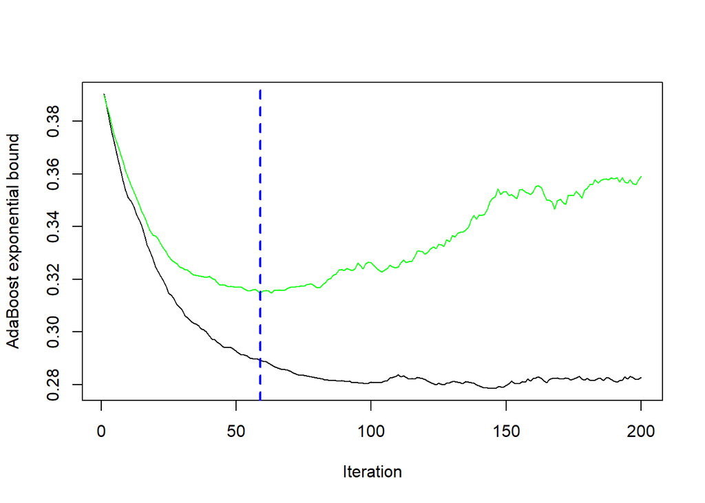

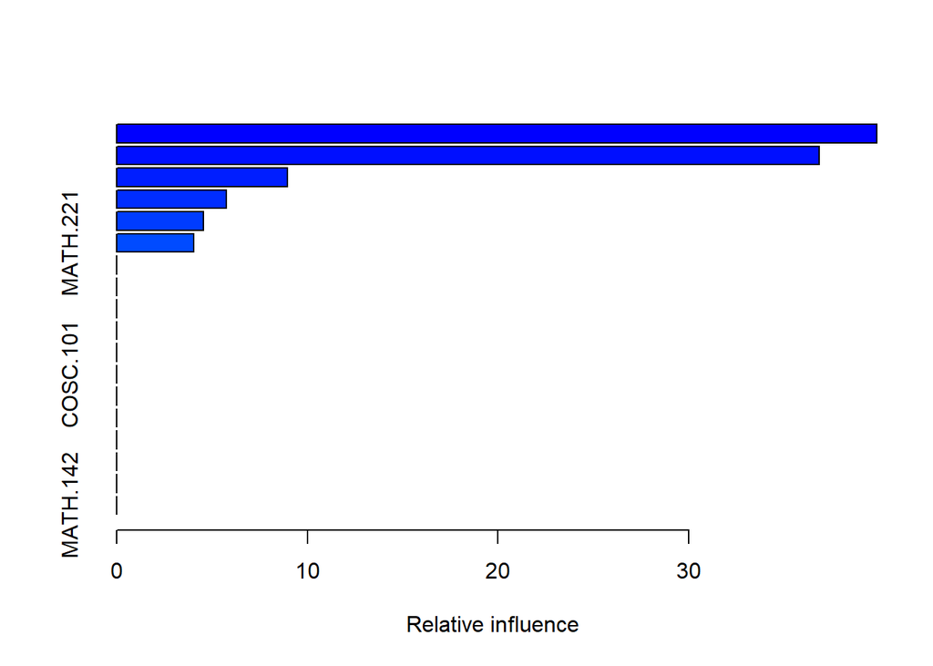

```
##               var   rel.inf
## COSC.211 COSC.211 39.849120
## MATH.200 MATH.200 36.832705
## COSC.111 COSC.111  8.945840
## MATH.225 MATH.225  5.768916
## COSC.121 COSC.121  4.569055
## MATH.221 MATH.221  4.034364
## MATH.100 MATH.100  0.000000
## MATH.101 MATH.101  0.000000
## COSC.221 COSC.221  0.000000
## COSC.222 COSC.222  0.000000
## COSC.122 COSC.122  0.000000
## COSC.101 COSC.101  0.000000
## STAT.121 STAT.121  0.000000
## DATA.101 DATA.101  0.000000
## COSC.123 COSC.123  0.000000
## MATH.116 MATH.116  0.000000
## MATH.220 MATH.220  0.000000
## MATH.142 MATH.142  0.000000
```

```r
# Running model a second time with optimal # of trees
gbm_model <- gbm(STAT.230 ~ ., data = coursegrades[train_indices,], distribution = gbm_params$distribution,
                 n.trees = ntrees, interaction.depth = gbm_params$interaction.depth,
                 shrinkage = gbm_params$shrinkage, bag.fraction = gbm_params$bag.fraction,
                 train.fraction = gbm_params$train.fraction, n.minobsinnode = gbm_params$n.minobsinnode, cv.folds = 5)
# Print the summary of the trained model
print(summary(gbm_model))
```

```r
# Make predictions on new data
predictions <- predict(gbm_model, newdata = coursegrades[test_indices,], n.trees = ntrees)

# rmse <- sqrt(mean((predictions - coursegrades[test_indices,COI])^2))
# rmse
```